# Regions with changes in FIRE frequency - Genome wide analysis

Crystal Shan

2026-09-12

```r
library(ggplot2)
library(dplyr)
library(tidyr)
library(readr)
library(stringr)
library(ggpubr)
library(ggrepel)
library(tidyverse)
library(DT)
```

# FIRE frequency

region represents universe FIRE regions across all timepoints

```r
input_dir <- "/project/spott/cshan/fiber-seq/macrophage_project/fire_frequency"

fire_freq <- read.csv(file.path(input_dir, "fire_frequency_long.tsv.gz"), sep = "\t")
head(fire_freq)
```

```
##   chrom start   end        region_id timepoint n_reads n_fire     freq
## 1  chr1 11261 11486 chr1:11261-11486     LPS_0      12      2 0.166667
## 2  chr1 21178 21359 chr1:21178-21359     LPS_0      72      9 0.125000
## 3  chr1 28997 29166 chr1:28997-29166     LPS_0      26     12 0.461538
## 4  chr1 29283 29478 chr1:29283-29478     LPS_0      25     23 0.920000
## 5  chr1 29964 30121 chr1:29964-30121     LPS_0      24      6 0.250000
## 6  chr1 38601 38804 chr1:38601-38804     LPS_0      19      5 0.263158
```

```r
# group by region_id and timepoint, and calculate the mean frequency
fire_freq_summary <- fire_freq %>%
  group_by(region_id, timepoint) %>%
  summarise(mean_freq = mean(freq, na.rm = TRUE)) %>%
  ungroup()
```

[output not shown]

```r
# rank region by mean frequency for each timepoint
fire_freq_summary <- fire_freq_summary %>%
  group_by(timepoint) %>%
  mutate(rank = rank(-mean_freq, ties.method = "first")) %>%
  ungroup()

head(fire_freq_summary)
```

```
## # A tibble: 6 × 4
##   region_id                 timepoint mean_freq   rank
##   <chr>                     <chr>         <dbl>  <int>
## 1 chr10:100006359-100006588 LPS_0         0.344  89719
## 2 chr10:100006359-100006588 LPS_10        0.571  43226
## 3 chr10:100006359-100006588 LPS_15        0.370  80139
## 4 chr10:100006359-100006588 LPS_5         0.474  59365
## 5 chr10:100006712-100006884 LPS_0         0.355  86787
## 6 chr10:100006712-100006884 LPS_10        0.167 133857
```

# cumulative distribution of FIRE frequency for each timepoint

for a given frequency x, what fraction of FIRE-universe regions have frequency ≤ x?

Left-shifted curve = more regions accumulate at lower x values → overall lower FIRE frequencies

```r
fire_freq_cdf <- fire_freq_summary %>%
  filter(!is.na(mean_freq)) %>%
  group_by(timepoint) %>%
  arrange(mean_freq, .by_group = TRUE) %>%
  mutate(
    cdf = row_number() / n()
  ) %>%
  ungroup()

head(fire_freq_cdf)
```

```
## # A tibble: 6 × 5
##   region_id                 timepoint mean_freq   rank        cdf
##   <chr>                     <chr>         <dbl>  <int>      <dbl>
## 1 chr10:102801690-102801878 LPS_0             0 142835 0.00000699
## 2 chr10:113361011-113361200 LPS_0             0 142836 0.0000140
## 3 chr10:116742822-116742973 LPS_0             0 142837 0.0000210
## 4 chr10:119533192-119533331 LPS_0             0 142838 0.0000280
## 5 chr10:121159267-121159500 LPS_0             0 142839 0.0000349
## 6 chr10:124144848-124144962 LPS_0             0 142840 0.0000419
```

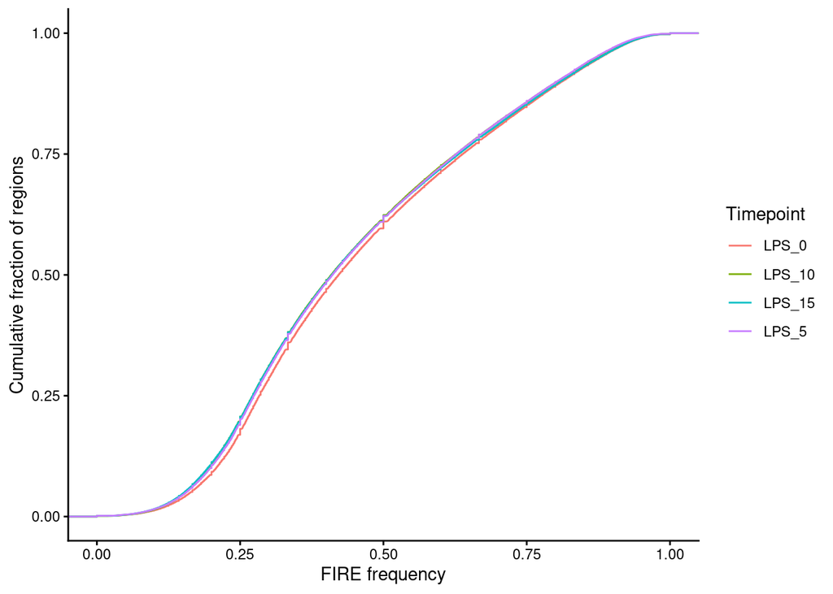

```r
p_freq_cdf <- ggplot(fire_freq_cdf, aes(x = mean_freq, color = timepoint)) +
  stat_ecdf(na.rm = TRUE) +
  labs(
    x = "FIRE frequency",
    y = "Cumulative fraction of regions",
    color = "Timepoint"
  ) +
  theme_classic()
p_freq_cdf
```

# Pairwise differential FIRE frequency: top 100 regions

Top 100 regions per comparison, ranked by Fisher exact p-value among coverage-passing regions (6 comparisons x 100 rows).

```r
pairwise <- read_tsv(file.path(input_dir, "pairwise_fisher.tsv.gz"),
                     show_col_types = FALSE)

comparison_levels <- c("LPS_0_vs_LPS_5", "LPS_0_vs_LPS_10", "LPS_0_vs_LPS_15",
                       "LPS_5_vs_LPS_10", "LPS_5_vs_LPS_15", "LPS_10_vs_LPS_15")
pairwise <- pairwise %>%
  mutate(comparison = factor(comparison, levels = comparison_levels))

# only coverage-passing regions were ranked in 02_pairwise_differential.R
passing <- pairwise %>% filter(pass_coverage)

# top 100 per comparison by raw p
top100 <- passing %>%
  group_by(comparison) %>%
  arrange(p_value, .by_group = TRUE) %>%
  slice_head(n = 100) %>%
  ungroup() %>%
  mutate(direction = ifelse(delta_freq > 0, "gain", "loss"))

# gain = higher FIRE frequency at the later timepoint
table(top100$comparison, top100$direction)
```

```
##
##                    gain loss
##   LPS_0_vs_LPS_5     35   65
##   LPS_0_vs_LPS_10    30   70
##   LPS_0_vs_LPS_15    49   51
##   LPS_5_vs_LPS_10    55   45
##   LPS_5_vs_LPS_15    62   38
##   LPS_10_vs_LPS_15   61   39
```

# Regions tested vs significant

Tested = coverage-passing regions in that comparison; significant = unadjusted Fisher p < 0.05. “any comparison” is the union across the 6 comparisons, i.e. the definition used in the cCRE section below.

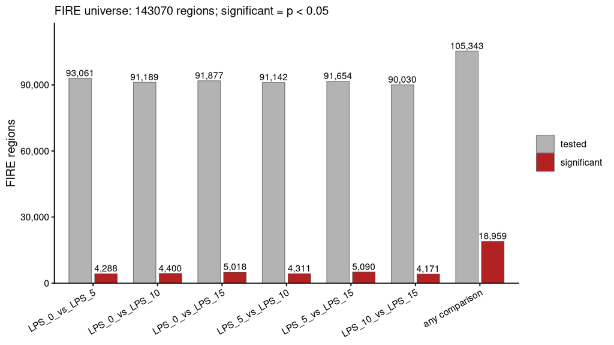

```r
p_sig <- 0.05

counts_by_comparison <- passing %>%
  group_by(comparison) %>%
  summarise(tested      = n(),
            significant = sum(p_value < p_sig),
            .groups = "drop") %>%
  mutate(group = as.character(comparison))

counts_union <- tibble(
  group       = "any comparison",
  tested      = n_distinct(passing$region_id),
  significant = n_distinct(passing$region_id[passing$p_value < p_sig]))

region_counts <- bind_rows(counts_by_comparison %>% select(group, tested, significant),
                           counts_union) %>%
  mutate(group = factor(group, levels = c(comparison_levels, "any comparison")))

region_counts_long <- region_counts %>%
  pivot_longer(c(tested, significant), names_to = "category", values_to = "n") %>%
  mutate(category = factor(category, levels = c("tested", "significant")))

p_region_counts <- ggplot(region_counts_long, aes(x = group, y = n, fill = category)) +
  geom_col(position = position_dodge(width = 0.8), width = 0.7,
           color = "grey30", linewidth = 0.2) +
  geom_text(aes(label = scales::comma(n)), position = position_dodge(width = 0.8),
            vjust = -0.3, size = 3) +
  scale_fill_manual(values = c(tested = "grey70", significant = "firebrick")) +
  scale_y_continuous(labels = scales::comma,
                     expand = expansion(mult = c(0, 0.12))) +
  labs(x = NULL, y = "FIRE regions", fill = NULL,
       subtitle = paste0("FIRE universe: ", n_distinct(pairwise$region_id),
                         " regions; significant = p < ", p_sig)) +
  theme_classic() +
  theme(axis.text.x = element_text(angle = 30, hjust = 1))
p_region_counts
```

```r
region_counts %>% mutate(frac_signif = round(significant / tested, 3))
```

```
## # A tibble: 7 × 4
##   group            tested significant frac_signif
##   <fct>             <int>       <int>       <dbl>
## 1 LPS_0_vs_LPS_5    93061        4288       0.046
## 2 LPS_0_vs_LPS_10   91189        4400       0.048
## 3 LPS_0_vs_LPS_15   91877        5018       0.055
## 4 LPS_5_vs_LPS_10   91142        4311       0.047
## 5 LPS_5_vs_LPS_15   91654        5090       0.056
## 6 LPS_10_vs_LPS_15  90030        4171       0.046
## 7 any comparison   105343       18959       0.18
```

# P-value distribution per comparison

Histogram of the unadjusted Fisher p-values

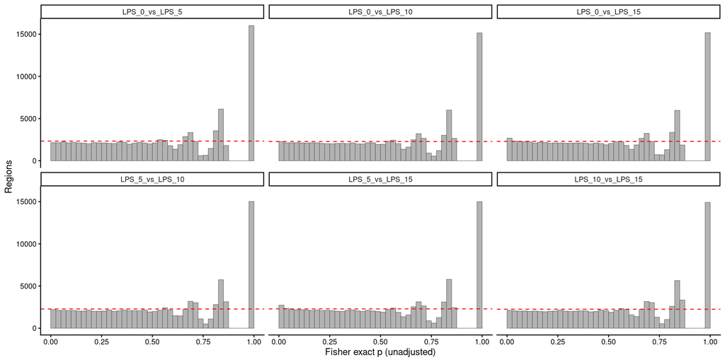

```r
expected_bin <- passing %>%
  count(comparison) %>%
  mutate(expected = n * 0.025)

p_pval_hist <- ggplot(passing, aes(x = p_value)) +
  geom_histogram(binwidth = 0.025, boundary = 0,
                 fill = "grey70", color = "grey30", linewidth = 0.2) +
  geom_hline(data = expected_bin, aes(yintercept = expected),
             linetype = "dashed", color = "red") +
  facet_wrap(~ comparison, nrow = 2) +
  labs(x = "Fisher exact p (unadjusted)", y = "Regions") +
  theme_classic()
p_pval_hist
```

# Volcano: effect size vs significance

Effect size = delta_freq (later - earlier FIRE frequency); significance = -log10 of the unadjusted Fisher p. Coverage-passing regions only. Points are coloured by direction among the regions with p < 0.05.

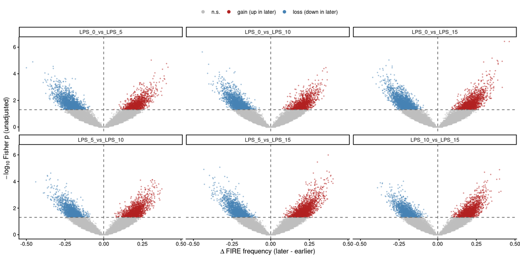

```r
volcano <- passing %>%
  mutate(neglog10_p = -log10(p_value),
         status = case_when(p_value >= p_sig  ~ "n.s.",
                            delta_freq > 0    ~ "gain (up in later)",
                            TRUE              ~ "loss (down in later)"),
         status = factor(status, levels = c("n.s.", "gain (up in later)",
                                            "loss (down in later)")))

status_cols <- c("n.s." = "grey75",
                 "gain (up in later)" = "firebrick",
                 "loss (down in later)" = "steelblue")

p_volcano <- ggplot(volcano, aes(x = delta_freq, y = neglog10_p, color = status)) +
  geom_point(size = 0.4, alpha = 0.4) +
  geom_hline(yintercept = -log10(p_sig), linetype = "dashed", color = "grey40") +
  geom_vline(xintercept = 0, linetype = "dashed", color = "grey40") +
  facet_wrap(~ comparison, nrow = 2) +
  scale_color_manual(values = status_cols) +
  guides(color = guide_legend(override.aes = list(size = 2, alpha = 1))) +
  labs(x = expression(Delta ~ "FIRE frequency (later - earlier)"),
       y = expression(-log[10] ~ "Fisher p (unadjusted)"), color = NULL) +
  theme_classic() +
  theme(legend.position = "top")
p_volcano
```

## LPS_0 vs LPS_15: regions gained and lost at 15 min

Same volcano restricted to the 0 vs 15 min comparison. Labelled points are the top 10 in each direction: p < 0.05 and the largest |delta_freq|, i.e. the regions with the highest FIRE frequency at 15 min relative to 0 (gains) and the lowest at 15 min relative to 0 (losses).

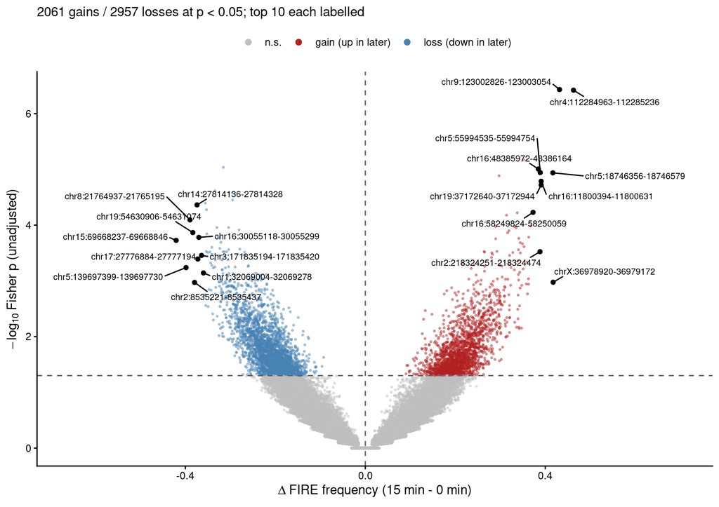

```r
n_label <- 10

v15 <- volcano %>% filter(comparison == "LPS_0_vs_LPS_15")

top_gain_15 <- v15 %>%
  filter(p_value < p_sig, delta_freq > 0) %>%
  arrange(desc(delta_freq), p_value) %>%
  mutate(rank = row_number(), direction = "gain")

top_loss_15 <- v15 %>%
  filter(p_value < p_sig, delta_freq < 0) %>%
  arrange(delta_freq, p_value) %>%
  mutate(rank = row_number(), direction = "loss")

labelled_15 <- bind_rows(head(top_gain_15, n_label), head(top_loss_15, n_label))

p_volcano_15 <- ggplot(v15, aes(x = delta_freq, y = neglog10_p, color = status)) +
  geom_point(size = 0.5, alpha = 0.4) +
  geom_hline(yintercept = -log10(p_sig), linetype = "dashed", color = "grey40") +
  geom_vline(xintercept = 0, linetype = "dashed", color = "grey40") +
  geom_point(data = labelled_15, color = "black", size = 1.4) +
  geom_text_repel(data = labelled_15, aes(label = region_id),
                  color = "black", size = 2.6, min.segment.length = 0,
                  max.overlaps = Inf, box.padding = 0.4) +
  scale_color_manual(values = status_cols) +

  scale_x_continuous(expand = expansion(mult = c(0.35, 0.35))) +
  guides(color = guide_legend(override.aes = list(size = 2, alpha = 1))) +
  labs(x = expression(Delta ~ "FIRE frequency (15 min - 0 min)"),
       y = expression(-log[10] ~ "Fisher p (unadjusted)"), color = NULL,
       subtitle = paste0(nrow(top_gain_15), " gains / ", nrow(top_loss_15),
                         " losses at p < ", p_sig,
                         "; top ", n_label, " each labelled")) +
  theme_classic() +
  theme(legend.position = "top")
p_volcano_15
```

```r
top_15 <- bind_rows(top_gain_15, top_loss_15)
write_tsv(top_15, file.path(input_dir, "top_changed_LPS_0_vs_LPS_15.tsv"))

# shared column layout for the two direction tables
format_top15 <- function(d) {
  d %>%
    transmute(rank, region_id,
              n_reads_0 = n_reads_A, freq_0 = round(freq_A, 3),
              n_reads_15 = n_reads_B, freq_15 = round(freq_B, 3),
              delta_freq = round(delta_freq, 3), log2_or = round(log2_or, 2),
              p_value = signif(p_value, 3))
}
```

Gains: higher FIRE frequency at 15 min than at 0, ranked by delta_freq.

```r
datatable(format_top15(top_gain_15), filter = "top", rownames = FALSE,
          caption = paste0("LPS_0 vs LPS_15 gains (p < ", p_sig, "): ",
                           nrow(top_gain_15), " regions"),
          options = list(pageLength = 10))
```

| rank | region_id | n_reads_0 | freq_0 | n_reads_15 | freq_15 | delta_freq | log2_or | p_value |
| --- | --- | --- | --- | --- | --- | --- | --- | --- |
| 1 | chr4:112284963-112285236 | 51 | 0.137 | 65 | 0.6 | 0.463 | 3.14 | 3.79e-07 |
| 2 | chr9:123002826-123003054 | 62 | 0.452 | 60 | 0.883 | 0.432 | 3.11 | 3.69e-07 |
| 3 | chrX:36978920-36979172 | 31 | 0.194 | 36 | 0.611 | 0.418 | 2.61 | 0.00106 |
| 4 | chr5:18746356-18746579 | 53 | 0.321 | 61 | 0.738 | 0.417 | 2.52 | 1.15e-05 |
| 5 | chr19:37172640-37172944 | 57 | 0.228 | 63 | 0.619 | 0.391 | 2.41 | 1.9e-05 |
| 6 | chr16:11800394-11800631 | 66 | 0.409 | 55 | 0.8 | 0.391 | 2.47 | 1.63e-05 |
| 7 | chr5:55994535-55994754 | 56 | 0.375 | 72 | 0.764 | 0.389 | 2.39 | 1.14e-05 |
| 8 | chr2:218324251-218324474 | 37 | 0.243 | 57 | 0.632 | 0.388 | 2.35 | 0.000299 |
| 9 | chr16:48385972-48386164 | 52 | 0.115 | 66 | 0.5 | 0.385 | 2.84 | 9.84e-06 |
| 10 | chr16:58249824-58250059 | 59 | 0.424 | 59 | 0.797 | 0.373 | 2.36 | 5.9e-05 |

[output cut: 2051 more lines]

Losses: lower FIRE frequency at 15 min than at 0, ranked by the most negative delta_freq.

```r
datatable(format_top15(top_loss_15), filter = "top", rownames = FALSE,
          caption = paste0("LPS_0 vs LPS_15 losses (p < ", p_sig, "): ",
                           nrow(top_loss_15), " regions"),
          options = list(pageLength = 10))
```

| rank | region_id | n_reads_0 | freq_0 | n_reads_15 | freq_15 | delta_freq | log2_or | p_value |
| --- | --- | --- | --- | --- | --- | --- | --- | --- |
| 1 | chr15:69668237-69668846 | 39 | 0.821 | 40 | 0.4 | -0.421 | -2.69 | 0.000188 |
| 2 | chr5:139697399-139697730 | 33 | 0.848 | 40 | 0.45 | -0.398 | -2.66 | 0.000578 |
| 3 | chr8:21764937-21765195 | 52 | 0.654 | 53 | 0.264 | -0.39 | -2.34 | 8.04e-05 |
| 4 | chr19:54630906-54631074 | 40 | 0.55 | 54 | 0.167 | -0.383 | -2.54 | 0.000136 |
| 5 | chr2:8535221-8535437 | 34 | 0.618 | 42 | 0.238 | -0.38 | -2.3 | 0.00106 |
| 6 | chr14:27814136-27814328 | 55 | 0.564 | 58 | 0.19 | -0.374 | -2.41 | 4.33e-05 |
| 7 | chr17:27776884-27777194 | 44 | 0.636 | 53 | 0.264 | -0.372 | -2.23 | 0.000405 |
| 8 | chr16:30055118-30055299 | 50 | 0.62 | 56 | 0.25 | -0.37 | -2.24 | 0.000166 |
| 9 | chr3:171835194-171835420 | 53 | 0.717 | 51 | 0.353 | -0.364 | -2.17 | 0.000349 |
| 10 | chr1:32069004-32069278 | 48 | 0.604 | 45 | 0.244 | -0.36 | -2.18 | 0.00072 |

[output cut: 2947 more lines]

# QQ plot: observed vs null p-values

Do Fisher’s p values from FIRE frequency comparisons contain more small p values than expected if there were no real differences between timepoints?

1. For each pairwise comparison, all coverage passing regions are ranked from smallest to largest p values, the observed fisher p-vlaue for each region is converted to -log10(p), and is plotted against the -log10(p) expected at the same rank if all p values follow a unifomr (0,1) null distribution
2. Points above the diagonal means there are more very small p values than expected

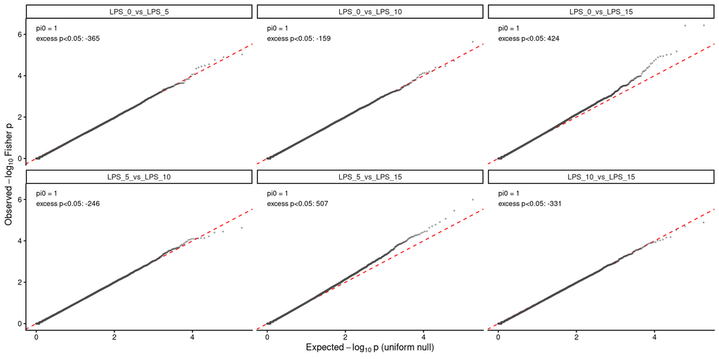

```r
qq <- passing %>%
  group_by(comparison) %>%
  arrange(p_value, .by_group = TRUE) %>%
  # convert to -log(10) based p value
  mutate(observed = -log10(p_value),
         # expected p value at the same rank if all regions are null
         expected = -log10((row_number() - 0.5) / n())) %>%
  ungroup()

pi0_tab <- passing %>%
  group_by(comparison) %>%
  # count how many regions are tested in each pairwise comparison
  summarise(tested = n(),
            # fraction of tests behave like null hypothesis
            pi0    = min(1, mean(p_value > 0.5) / 0.5),
            # number of regions with fisher p value < 0.05
            signif = sum(p_value < p_sig),
            .groups = "drop") %>%
  # estimated number of sig regions from the null hypothesis alone
  mutate(expected_null_signif = round(pi0 * tested * p_sig),
         excess               = signif - expected_null_signif)

# keeps the 5000 smallest p values
qq_thin <- qq %>%
  group_by(comparison) %>%
  filter(row_number() <= 5000 | row_number() %% 20 == 0) %>%
  ungroup()

# summary table
pi0_lab <- pi0_tab %>%
  mutate(label = paste0("pi0 = ", round(pi0, 2),
                        "\nexcess p<", p_sig, ": ", scales::comma(excess)))

# qq plot
  # x = expected -log10(p)
  # y = observed -log10(fisher p)
p_qq <- ggplot(qq_thin, aes(x = expected, y = observed)) +
  geom_abline(slope = 1, intercept = 0, color = "red", linetype = "dashed") +
  geom_point(size = 0.4, alpha = 0.4, color = "grey30") +
  geom_text(data = pi0_lab, aes(x = 0, y = max(qq$observed), label = label),
            hjust = 0, vjust = 1, size = 3, inherit.aes = FALSE) +
  facet_wrap(~ comparison, nrow = 2) +
  labs(x = expression("Expected" ~ -log[10] ~ "p (uniform null)"),
       y = expression("Observed" ~ -log[10] ~ "Fisher p")) +
  theme_classic()
p_qq
```

```r
pi0_tab %>% mutate(pi0 = round(pi0, 3))
```

```
## # A tibble: 6 × 6
##   comparison       tested   pi0 signif expected_null_signif excess
##   <fct>             <int> <dbl>  <int>                <dbl>  <dbl>
## 1 LPS_0_vs_LPS_5    93061     1   4288                 4653   -365
## 2 LPS_0_vs_LPS_10   91189     1   4400                 4559   -159
## 3 LPS_0_vs_LPS_15   91877     1   5018                 4594    424
## 4 LPS_5_vs_LPS_10   91142     1   4311                 4557   -246
## 5 LPS_5_vs_LPS_15   91654     1   5090                 4583    507
## 6 LPS_10_vs_LPS_15  90030     1   4171                 4502   -331
```

# Significant regions vs ENCODE cCREs

Significant = unadjusted Fisher p < 0.05 in at least one of the 6 pairwise comparisons

`ccre_class` / `ccre_id` report that best cCRE.

```r
suppressPackageStartupMessages(library(GenomicRanges))

ccre_file <- "/project/spott/cshan/annotations/GRCh38-cCREs.bed"
p_sig <- 0.05

signif_rows <- passing %>% filter(p_value < p_sig)

# region level: keep the samllest p comparison for ranking
signif_regions <- signif_rows %>%
  group_by(region_id, chrom, start, end) %>%
  summarise(n_signif_comparisons = n(),
            min_p           = min(p_value),
            best_comparison = comparison[which.min(p_value)],
            delta_freq_best = delta_freq[which.min(p_value)],
            .groups = "drop")

ccre <- data.table::fread(ccre_file, header = FALSE,
                          col.names = c("chr", "start", "end",
                                        "ccre_dcc", "ccre_id", "ccre_class"))

reg.gr  <- GRanges(signif_regions$chrom,
                   IRanges(signif_regions$start + 1L, signif_regions$end))
ccre.gr <- GRanges(ccre$chr, IRanges(ccre$start + 1L, ccre$end))
hits <- findOverlaps(reg.gr, ccre.gr)
ov_frac <- width(pintersect(reg.gr[queryHits(hits)], ccre.gr[subjectHits(hits)])) /
  width(reg.gr)[queryHits(hits)]

# best cCRE per region (largest covered fraction)
best <- data.frame(ri = queryHits(hits), frac = ov_frac,
                   ccre_id = ccre$ccre_id[subjectHits(hits)],
                   ccre_class = ccre$ccre_class[subjectHits(hits)]) %>%
  group_by(ri) %>%
  slice_max(frac, n = 1, with_ties = FALSE) %>%
  ungroup()

signif_regions <- signif_regions %>%
  mutate(ccre_frac = 0, ccre_id = NA_character_, ccre_class = NA_character_)
signif_regions$ccre_frac[best$ri]  <- best$frac
signif_regions$ccre_id[best$ri]    <- best$ccre_id
signif_regions$ccre_class[best$ri] <- best$ccre_class

signif_ccre <- signif_regions %>% filter(ccre_frac >= 0.5)

tibble(n_signif_regions = nrow(signif_regions),
       any_ccre_overlap = sum(signif_regions$ccre_frac > 0),
       ccre_50          = nrow(signif_ccre),
       frac_ccre_50     = round(nrow(signif_ccre) / nrow(signif_regions), 3))
```

```
## # A tibble: 1 × 4
##   n_signif_regions any_ccre_overlap ccre_50 frac_ccre_50
##              <int>            <int>   <int>        <dbl>
## 1            18959            18372   17468        0.921
```

Nearest gencode v46 gene for the cCRE-supported regions (distance 0 = overlapping the gene body)

```r
gtf_file <- "/project/spott/cshan/annotations/gencode.v46.annotation.gtf.gz"
gtf <- data.table::fread(cmd = paste("zcat", gtf_file, "| awk -F'\\t' '$3==\"gene\"'"),
                         header = FALSE, sep = "\t")
genes.gr <- GRanges(gtf$V1, IRanges(gtf$V4, gtf$V5),
                    gene_name = sub('.*gene_name "([^"]+)".*', "\\1", gtf$V9),
                    gene_type = sub('.*gene_type "([^"]+)".*', "\\1", gtf$V9))

sc.gr <- GRanges(signif_ccre$chrom, IRanges(signif_ccre$start + 1L, signif_ccre$end))
d <- distanceToNearest(sc.gr, genes.gr)
signif_ccre$nearest_gene  <- NA_character_
signif_ccre$nearest_gene_type <- NA_character_
signif_ccre$gene_distance <- NA_integer_
signif_ccre$nearest_gene[queryHits(d)]      <- genes.gr$gene_name[subjectHits(d)]
signif_ccre$nearest_gene_type[queryHits(d)] <- genes.gr$gene_type[subjectHits(d)]
signif_ccre$gene_distance[queryHits(d)] <- mcols(d)$distance

write_tsv(signif_ccre %>% arrange(min_p),
          file.path(input_dir, "signif_ccre_regions.tsv"))
```

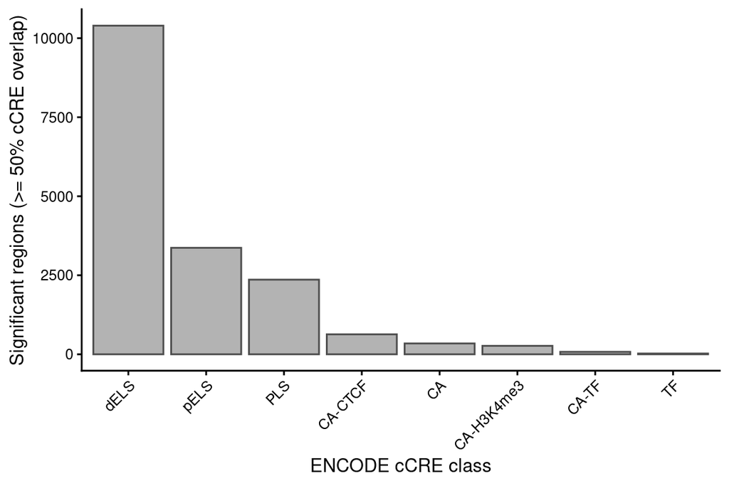

```r
p_ccre_class <- signif_ccre %>%
  count(ccre_class) %>%
  ggplot(aes(x = reorder(ccre_class, -n), y = n)) +
  geom_col(fill = "grey70", color = "grey30") +
  labs(x = "ENCODE cCRE class",
       y = "Significant regions (>= 50% cCRE overlap)") +
  theme_classic() +
  theme(axis.text.x = element_text(angle = 45, hjust = 1))
p_ccre_class
```

Top 100 cCRE-supported significant regions by best p (full table in `signif_ccre_regions.tsv`).

```r
signif_ccre %>%
  arrange(min_p) %>%
  head(100) %>%
  transmute(region_id, best_comparison, n_signif_comparisons,
            min_p = signif(min_p, 3),
            delta_freq_best = round(delta_freq_best, 3),
            ccre_id, ccre_class, ccre_frac = round(ccre_frac, 2),
            nearest_gene, gene_distance) %>%
  datatable(filter = "top", rownames = FALSE, options = list(pageLength = 20))
```

| region_id | best_comparison | n_signif_comparisons | min_p | delta_freq_best | ccre_id | ccre_class | ccre_frac | nearest_gene | gene_distance |
| --- | --- | --- | --- | --- | --- | --- | --- | --- | --- |
| chr9:123002826-123003054 | LPS_0_vs_LPS_15 | 4 | 3.69e-07 | 0.432 | EH38E2724926 | dELS | 1 | RABGAP1 | 0 |
| chr4:112284963-112285236 | LPS_0_vs_LPS_15 | 4 | 3.79e-07 | 0.463 | EH38E3600302 | pELS | 1 | TIFA | 0 |
| chr17:66985490-66985682 | LPS_5_vs_LPS_15 | 3 | 1.02e-06 | 0.372 | EH38E3238659 | dELS | 1 | CACNG4 | 0 |
| chr3:42524832-42525054 | LPS_0_vs_LPS_10 | 4 | 2.3e-06 | -0.443 | EH38E3508189 | dELS | 1 | VIPR1-AS1 | 0 |
| chr2:55585837-55586002 | LPS_5_vs_LPS_15 | 3 | 3.46e-06 | 0.302 | EH38E1999514 | dELS | 1 | PPP4R3B | 0 |
| chr17:49646926-49647120 | LPS_0_vs_LPS_15 | 3 | 6.7e-06 | 0.352 | EH38E3229286 | pELS | 0.88 | SPOP | 0 |
| chr5:62939099-62939230 | LPS_5_vs_LPS_15 | 4 | 8.49e-06 | -0.329 | EH38E3639815 | dELS | 1 | ENSG00000249579 | 83688 |
| chr5:68405116-68405304 | LPS_0_vs_LPS_15 | 4 | 9.2e-06 | -0.315 | EH38E3641466 | dELS | 0.95 | ENSG00000248884 | 25034 |
| chr21:13846861-13847022 | LPS_0_vs_LPS_5 | 4 | 9.38e-06 | 0.308 | EH38E4269910 | CA-TF | 1 | CYP4F29P | 0 |
| chr16:48385972-48386164 | LPS_0_vs_LPS_15 | 3 | 9.84e-06 | 0.385 | EH38E3178910 | pELS | 1 | SIAH1 | 0 |

[output cut: 90 more lines]

# Read-level plots: top 10 cCRE-supported differential regions

```r
code_dir <- "/project/spott/cshan/fiber-seq/code/topic_model/read_region_extraction"
source(file.path(code_dir, "region_data_utils.R"))
source(file.path(code_dir, "region_plot_functions.R"))
```

```r
options(scipen = 999)

extract_script <- file.path(code_dir, "extract_region_result_macrophage.sh")
extract_root <- "/project/spott/cshan/fiber-seq/macrophage_project/fire_frequency/region_plots"
sample_names <- c("LPS_0", "LPS_5", "LPS_10", "LPS_15")
pad <- 1000

# Keep the existing protein-coding nearest-gene filter and rank by best p-value.
top10 <- signif_ccre %>%
  filter(nearest_gene_type == "protein_coding") %>%
  arrange(min_p) %>%
  head(10) %>%
  mutate(rank = row_number(),
         outname = paste(chrom, start, end, sep = "_"),
         window_start = as.integer(start - pad),
         window_end   = as.integer(end + pad))
```

Top 10 cCRE-supported differential regions selected for read-level plots

| rank | region_id | best_comparison | min_p | delta_freq_best | ccre_id | ccre_class | ccre_frac | nearest_gene | gene_distance |
| --- | --- | --- | --- | --- | --- | --- | --- | --- | --- |
| 1 | chr9:123002826-123003054 | LPS_0_vs_LPS_15 | 3.693e-07 | 0.432 | EH38E2724926 | dELS | 1.00 | RABGAP1 | 0 |
| 2 | chr4:112284963-112285236 | LPS_0_vs_LPS_15 | 3.795e-07 | 0.463 | EH38E3600302 | pELS | 1.00 | TIFA | 0 |
| 3 | chr17:66985490-66985682 | LPS_5_vs_LPS_15 | 1.018e-06 | 0.372 | EH38E3238659 | dELS | 1.00 | CACNG4 | 0 |
| 4 | chr2:55585837-55586002 | LPS_5_vs_LPS_15 | 3.463e-06 | 0.302 | EH38E1999514 | dELS | 1.00 | PPP4R3B | 0 |
| 5 | chr17:49646926-49647120 | LPS_0_vs_LPS_15 | 6.700e-06 | 0.352 | EH38E3229286 | pELS | 0.88 | SPOP | 0 |
| 6 | chr16:48385972-48386164 | LPS_0_vs_LPS_15 | 9.845e-06 | 0.385 | EH38E3178910 | pELS | 1.00 | SIAH1 | 0 |
| 7 | chr11:114139252-114139464 | LPS_5_vs_LPS_15 | 1.235e-05 | -0.433 | EH38E2985470 | dELS | 1.00 | ZBTB16 | 0 |
| 8 | chr9:136363697-136363919 | LPS_10_vs_LPS_15 | 1.294e-05 | 0.400 | EH38E3919614 | PLS | 1.00 | ENSG00000289701 | 0 |
| 9 | chr18:28147665-28147835 | LPS_0_vs_LPS_15 | 1.300e-05 | 0.297 | EH38E3261868 | pELS | 1.00 | CDH2 | 0 |
| 10 | chr20:48761473-48761662 | LPS_0_vs_LPS_5 | 1.711e-05 | 0.406 | EH38E3437674 | dELS | 1.00 | PREX1 | 0 |

```
## === chr9:123002826-123003054 (dELS, nearest gene: RABGAP1) ===
## Loading LPS_0 from /project/spott/cshan/fiber-seq/macrophage_project/fire_frequency/region_plots/chr9_123002826_123003054/LPS_0/parsed
## Loading LPS_5 from /project/spott/cshan/fiber-seq/macrophage_project/fire_frequency/region_plots/chr9_123002826_123003054/LPS_5/parsed
## Loading LPS_10 from /project/spott/cshan/fiber-seq/macrophage_project/fire_frequency/region_plots/chr9_123002826_123003054/LPS_10/parsed
## Loading LPS_15 from /project/spott/cshan/fiber-seq/macrophage_project/fire_frequency/region_plots/chr9_123002826_123003054/LPS_15/parsed
## 315 reads in the region across 4 samples
## 2600 TF footprints, 437 of them inside a FIRE element
## 2051 nucleosome calls in 130-160 bp
## 315 reads in region result; 315 grouped; 0 dropped.
##
##          LPS_0 LPS_10 LPS_15 LPS_5
##   LPS_0     75      0      0     0
##   LPS_5      0      0      0    92
##   LPS_10     0     78      0     0
##   LPS_15     0      0     70     0
```

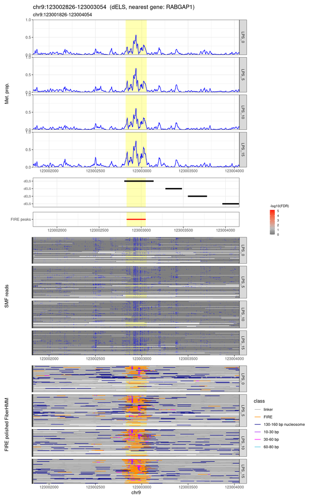

```
## === chr4:112284963-112285236 (pELS, nearest gene: TIFA) ===
## Loading LPS_0 from /project/spott/cshan/fiber-seq/macrophage_project/fire_frequency/region_plots/chr4_112284963_112285236/LPS_0/parsed
## Loading LPS_5 from /project/spott/cshan/fiber-seq/macrophage_project/fire_frequency/region_plots/chr4_112284963_112285236/LPS_5/parsed
## Loading LPS_10 from /project/spott/cshan/fiber-seq/macrophage_project/fire_frequency/region_plots/chr4_112284963_112285236/LPS_10/parsed
## Loading LPS_15 from /project/spott/cshan/fiber-seq/macrophage_project/fire_frequency/region_plots/chr4_112284963_112285236/LPS_15/parsed
## 259 reads in the region across 4 samples
## 3570 TF footprints, 1068 of them inside a FIRE element
## 2371 nucleosome calls in 130-160 bp
## 259 reads in region result; 259 grouped; 0 dropped.
##
##          LPS_0 LPS_10 LPS_15 LPS_5
##   LPS_0     63      0      0     0
##   LPS_5      0      0      0    59
##   LPS_10     0     65      0     0
##   LPS_15     0      0     72     0
```

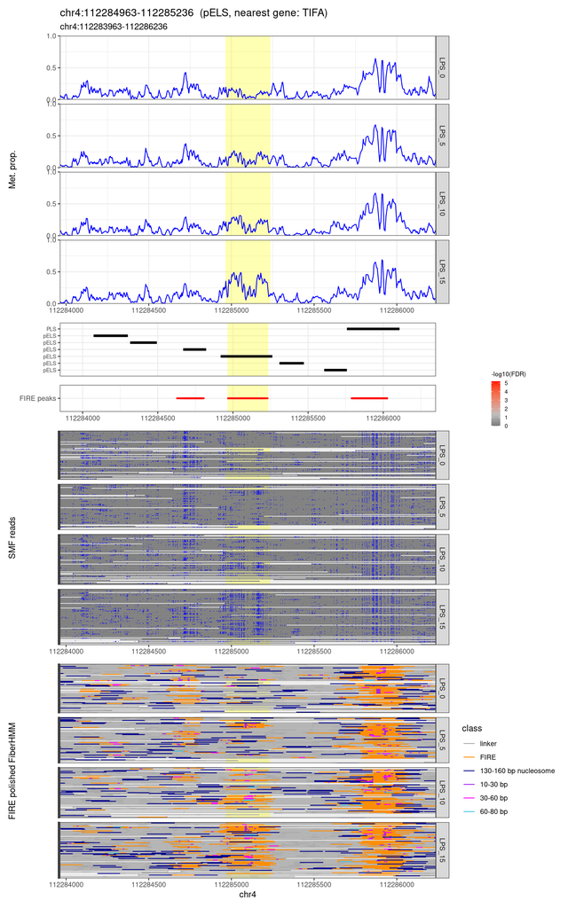

```
## === chr17:66985490-66985682 (dELS, nearest gene: CACNG4) ===
## Loading LPS_0 from /project/spott/cshan/fiber-seq/macrophage_project/fire_frequency/region_plots/chr17_66985490_66985682/LPS_0/parsed
## Loading LPS_5 from /project/spott/cshan/fiber-seq/macrophage_project/fire_frequency/region_plots/chr17_66985490_66985682/LPS_5/parsed
## Loading LPS_10 from /project/spott/cshan/fiber-seq/macrophage_project/fire_frequency/region_plots/chr17_66985490_66985682/LPS_10/parsed
## Loading LPS_15 from /project/spott/cshan/fiber-seq/macrophage_project/fire_frequency/region_plots/chr17_66985490_66985682/LPS_15/parsed
## 244 reads in the region across 4 samples
## 2125 TF footprints, 250 of them inside a FIRE element
## 1877 nucleosome calls in 130-160 bp
## 244 reads in region result; 244 grouped; 0 dropped.
##
##          LPS_0 LPS_10 LPS_15 LPS_5
##   LPS_0     63      0      0     0
##   LPS_5      0      0      0    58
##   LPS_10     0     71      0     0
##   LPS_15     0      0     52     0
```

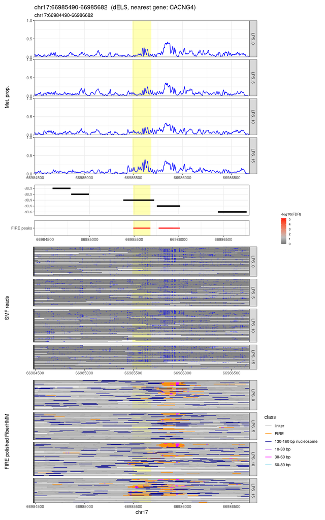

```
## === chr2:55585837-55586002 (dELS, nearest gene: PPP4R3B) ===
## Loading LPS_0 from /project/spott/cshan/fiber-seq/macrophage_project/fire_frequency/region_plots/chr2_55585837_55586002/LPS_0/parsed
## Loading LPS_5 from /project/spott/cshan/fiber-seq/macrophage_project/fire_frequency/region_plots/chr2_55585837_55586002/LPS_5/parsed
## Loading LPS_10 from /project/spott/cshan/fiber-seq/macrophage_project/fire_frequency/region_plots/chr2_55585837_55586002/LPS_10/parsed
## Loading LPS_15 from /project/spott/cshan/fiber-seq/macrophage_project/fire_frequency/region_plots/chr2_55585837_55586002/LPS_15/parsed
## 351 reads in the region across 4 samples
## 2605 TF footprints, 448 of them inside a FIRE element
## 2219 nucleosome calls in 130-160 bp
## 351 reads in region result; 351 grouped; 0 dropped.
##
##          LPS_0 LPS_10 LPS_15 LPS_5
##   LPS_0     89      0      0     0
##   LPS_5      0      0      0    70
##   LPS_10     0    107      0     0
##   LPS_15     0      0     85     0
```

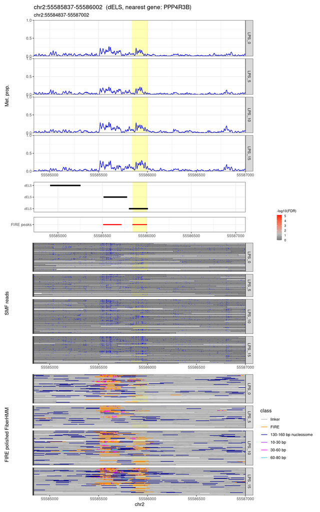

```
## === chr17:49646926-49647120 (pELS, nearest gene: SPOP) ===
## Loading LPS_0 from /project/spott/cshan/fiber-seq/macrophage_project/fire_frequency/region_plots/chr17_49646926_49647120/LPS_0/parsed
## Loading LPS_5 from /project/spott/cshan/fiber-seq/macrophage_project/fire_frequency/region_plots/chr17_49646926_49647120/LPS_5/parsed
## Loading LPS_10 from /project/spott/cshan/fiber-seq/macrophage_project/fire_frequency/region_plots/chr17_49646926_49647120/LPS_10/parsed
## Loading LPS_15 from /project/spott/cshan/fiber-seq/macrophage_project/fire_frequency/region_plots/chr17_49646926_49647120/LPS_15/parsed
## 332 reads in the region across 4 samples
## 2916 TF footprints, 356 of them inside a FIRE element
## 2705 nucleosome calls in 130-160 bp
## 332 reads in region result; 332 grouped; 0 dropped.
##
##          LPS_0 LPS_10 LPS_15 LPS_5
##   LPS_0     82      0      0     0
##   LPS_5      0      0      0    92
##   LPS_10     0     87      0     0
##   LPS_15     0      0     71     0
```

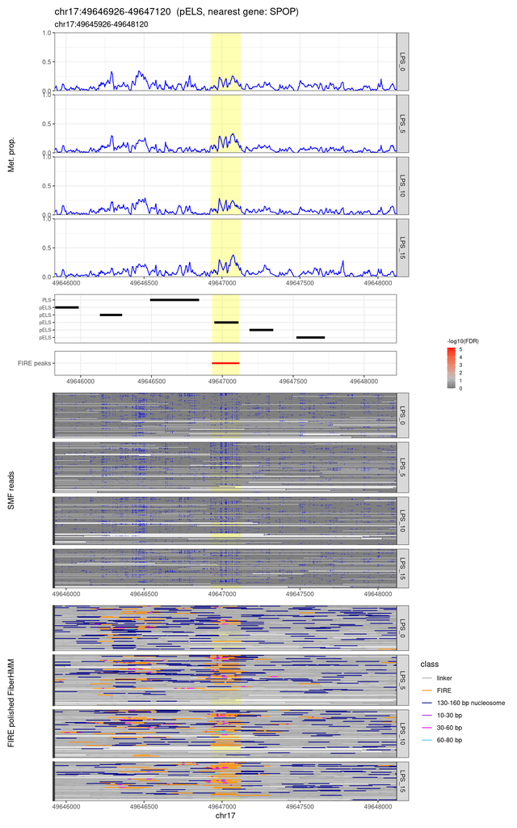

```
## === chr16:48385972-48386164 (pELS, nearest gene: SIAH1) ===
## Loading LPS_0 from /project/spott/cshan/fiber-seq/macrophage_project/fire_frequency/region_plots/chr16_48385972_48386164/LPS_0/parsed
## Loading LPS_5 from /project/spott/cshan/fiber-seq/macrophage_project/fire_frequency/region_plots/chr16_48385972_48386164/LPS_5/parsed
## Loading LPS_10 from /project/spott/cshan/fiber-seq/macrophage_project/fire_frequency/region_plots/chr16_48385972_48386164/LPS_10/parsed
## Loading LPS_15 from /project/spott/cshan/fiber-seq/macrophage_project/fire_frequency/region_plots/chr16_48385972_48386164/LPS_15/parsed
## 241 reads in the region across 4 samples
## 2724 TF footprints, 650 of them inside a FIRE element
## 2033 nucleosome calls in 130-160 bp
## 241 reads in region result; 241 grouped; 0 dropped.
##
##          LPS_0 LPS_10 LPS_15 LPS_5
##   LPS_0     62      0      0     0
##   LPS_5      0      0      0    56
##   LPS_10     0     53      0     0
##   LPS_15     0      0     70     0
```

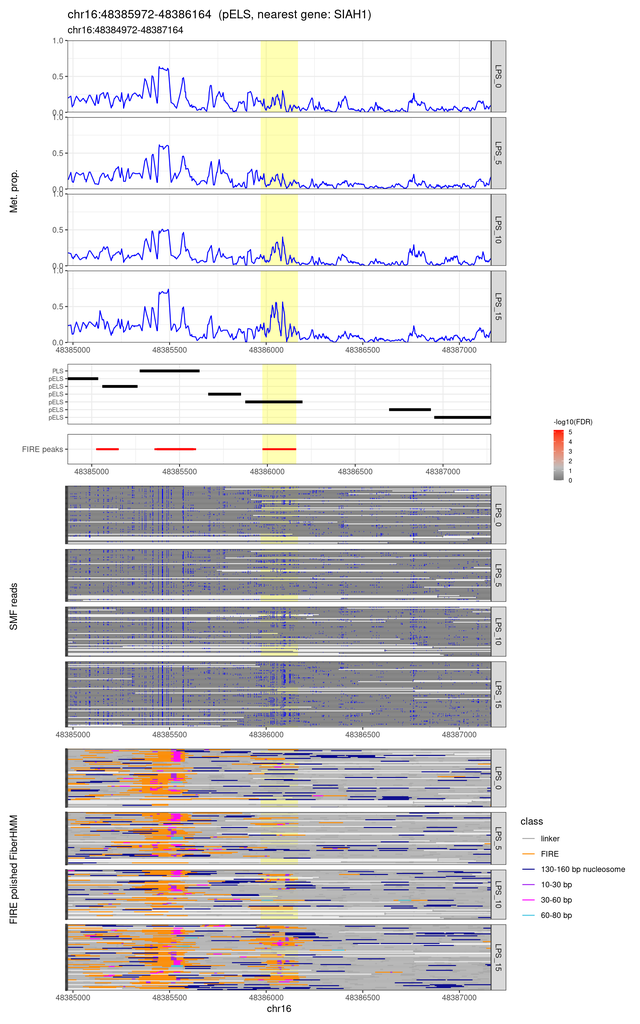

```
## === chr11:114139252-114139464 (dELS, nearest gene: ZBTB16) ===
## Loading LPS_0 from /project/spott/cshan/fiber-seq/macrophage_project/fire_frequency/region_plots/chr11_114139252_114139464/LPS_0/parsed
## Loading LPS_5 from /project/spott/cshan/fiber-seq/macrophage_project/fire_frequency/region_plots/chr11_114139252_114139464/LPS_5/parsed
## Loading LPS_10 from /project/spott/cshan/fiber-seq/macrophage_project/fire_frequency/region_plots/chr11_114139252_114139464/LPS_10/parsed
## Loading LPS_15 from /project/spott/cshan/fiber-seq/macrophage_project/fire_frequency/region_plots/chr11_114139252_114139464/LPS_15/parsed
## 253 reads in the region across 4 samples
## 2803 TF footprints, 668 of them inside a FIRE element
## 2073 nucleosome calls in 130-160 bp
## 253 reads in region result; 253 grouped; 0 dropped.
##
##          LPS_0 LPS_10 LPS_15 LPS_5
##   LPS_0     68      0      0     0
##   LPS_5      0      0      0    55
##   LPS_10     0     61      0     0
##   LPS_15     0      0     69     0
```

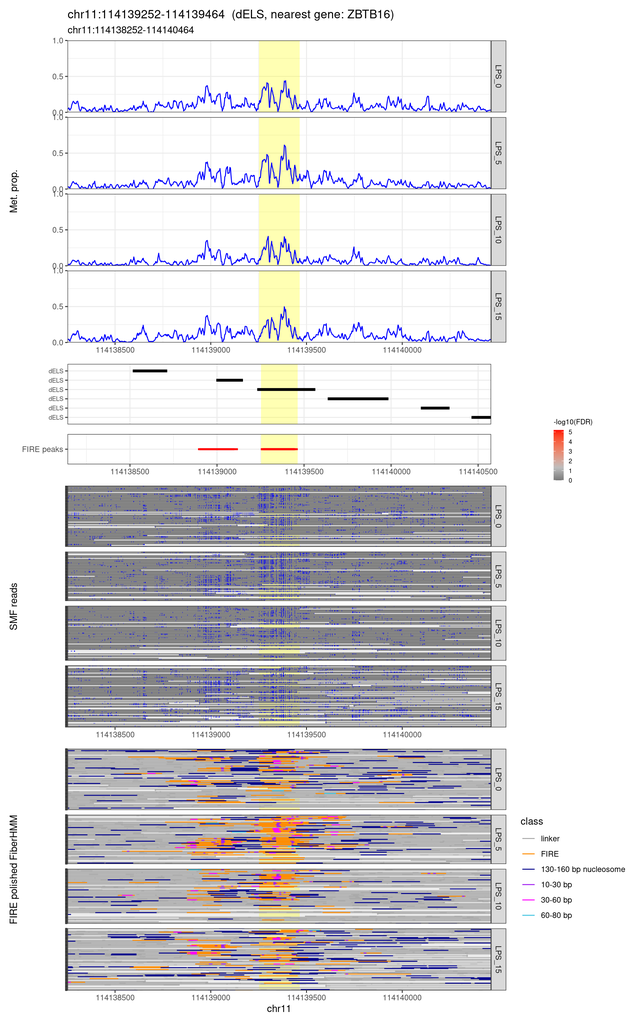

```
## === chr9:136363697-136363919 (PLS, nearest gene: ENSG00000289701) ===
## Loading LPS_0 from /project/spott/cshan/fiber-seq/macrophage_project/fire_frequency/region_plots/chr9_136363697_136363919/LPS_0/parsed
## Loading LPS_5 from /project/spott/cshan/fiber-seq/macrophage_project/fire_frequency/region_plots/chr9_136363697_136363919/LPS_5/parsed
## Loading LPS_10 from /project/spott/cshan/fiber-seq/macrophage_project/fire_frequency/region_plots/chr9_136363697_136363919/LPS_10/parsed
## Loading LPS_15 from /project/spott/cshan/fiber-seq/macrophage_project/fire_frequency/region_plots/chr9_136363697_136363919/LPS_15/parsed
## 272 reads in the region across 4 samples
## 2571 TF footprints, 811 of them inside a FIRE element
## 2546 nucleosome calls in 130-160 bp
## 272 reads in region result; 272 grouped; 0 dropped.
##
##          LPS_0 LPS_10 LPS_15 LPS_5
##   LPS_0     64      0      0     0
##   LPS_5      0      0      0    67
##   LPS_10     0     82      0     0
##   LPS_15     0      0     59     0
```

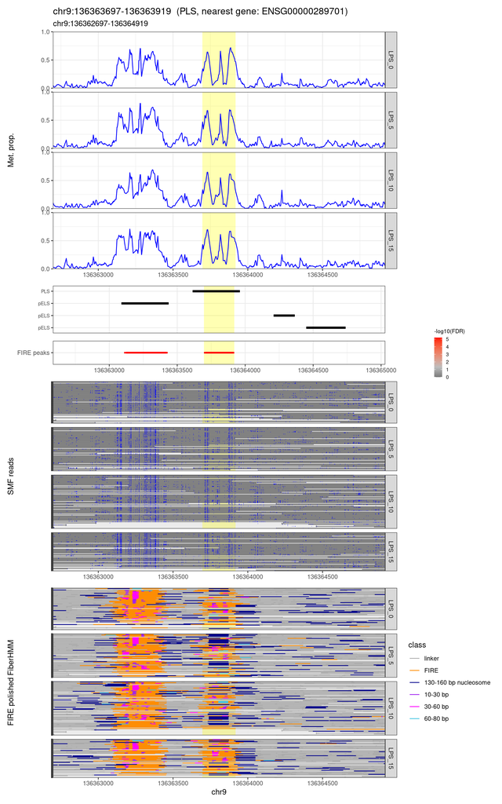

```
## === chr18:28147665-28147835 (pELS, nearest gene: CDH2) ===
## Loading LPS_0 from /project/spott/cshan/fiber-seq/macrophage_project/fire_frequency/region_plots/chr18_28147665_28147835/LPS_0/parsed
## Loading LPS_5 from /project/spott/cshan/fiber-seq/macrophage_project/fire_frequency/region_plots/chr18_28147665_28147835/LPS_5/parsed
## Loading LPS_10 from /project/spott/cshan/fiber-seq/macrophage_project/fire_frequency/region_plots/chr18_28147665_28147835/LPS_10/parsed
## Loading LPS_15 from /project/spott/cshan/fiber-seq/macrophage_project/fire_frequency/region_plots/chr18_28147665_28147835/LPS_15/parsed
## 297 reads in the region across 4 samples
## 2193 TF footprints, 154 of them inside a FIRE element
## 1900 nucleosome calls in 130-160 bp
## 297 reads in region result; 297 grouped; 0 dropped.
##
##          LPS_0 LPS_10 LPS_15 LPS_5
##   LPS_0     72      0      0     0
##   LPS_5      0      0      0    62
##   LPS_10     0     97      0     0
##   LPS_15     0      0     66     0
```

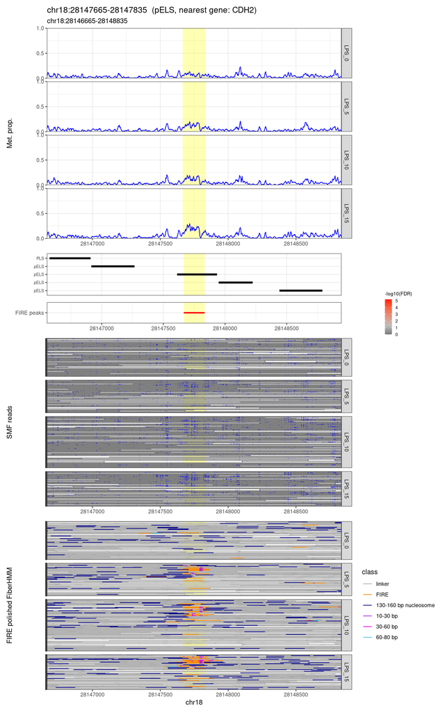

```
## === chr20:48761473-48761662 (dELS, nearest gene: PREX1) ===
## Loading LPS_0 from /project/spott/cshan/fiber-seq/macrophage_project/fire_frequency/region_plots/chr20_48761473_48761662/LPS_0/parsed
## Loading LPS_5 from /project/spott/cshan/fiber-seq/macrophage_project/fire_frequency/region_plots/chr20_48761473_48761662/LPS_5/parsed
## Loading LPS_10 from /project/spott/cshan/fiber-seq/macrophage_project/fire_frequency/region_plots/chr20_48761473_48761662/LPS_10/parsed
## Loading LPS_15 from /project/spott/cshan/fiber-seq/macrophage_project/fire_frequency/region_plots/chr20_48761473_48761662/LPS_15/parsed
## 243 reads in the region across 4 samples
## 2596 TF footprints, 807 of them inside a FIRE element
## 1775 nucleosome calls in 130-160 bp
## 243 reads in region result; 243 grouped; 0 dropped.
##
##          LPS_0 LPS_10 LPS_15 LPS_5
##   LPS_0     59      0      0     0
##   LPS_5      0      0      0    64
##   LPS_10     0     55      0     0
##   LPS_15     0      0     65     0
```

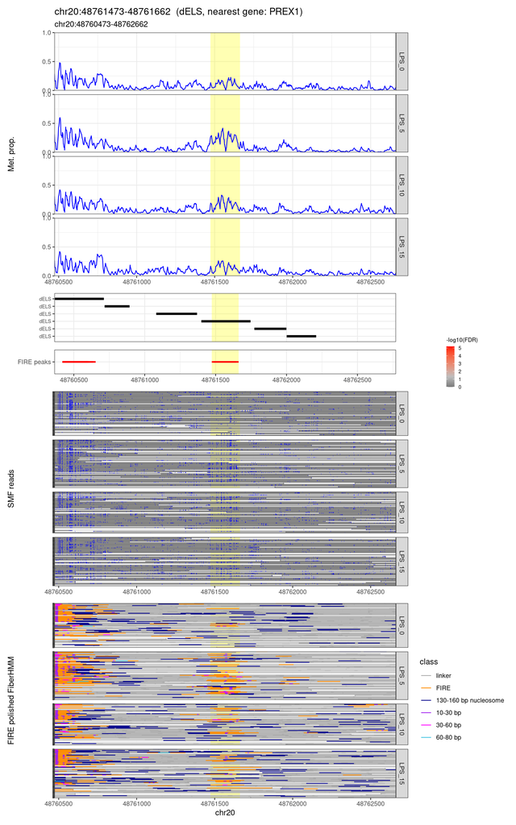

```r
for (i in seq_len(nrow(top10))) {
  row <- top10[i, ]
  cat("=== ", row$region_id, " (", row$ccre_class, ", nearest gene: ",
      row$nearest_gene, ") ===\n", sep = "")

  res <- load_region_results(
    region       = data.frame(chr = row$chrom, start = row$window_start,
                              end = row$window_end),
    sample_names = sample_names,
    result_dirs  = file.path(extract_root, row$outname, sample_names, "parsed"),
    fiberHMM_feature      = "tf",
    min_fiberHMM_fp_score = 50,
    fiberHMM_size_breaks  = c(10, 30, 60, 80))

  # facet the read-level panels and the pileup by timepoint
  res <- add_read_groups(res,
                         labels = setNames(as.character(res$rids_df$sample_name),
                                           as.character(res$rids_df$RID)),
                         group_col = "timepoint",
                         group_levels = sample_names)

  # cCREs in the window, one row per cCRE labelled with its class; the tested region
  # itself is the yellow band behind every panel
  peaks_df <- ccre %>%
    filter(chr == row$chrom, end > row$window_start, start < row$window_end) %>%
    arrange(ccre_class, start) %>%
    transmute(chr, start, end, group = ccre_class)

  p <- plot_region_panels(res,
                          plot_name = paste0(row$region_id, "  (", row$ccre_class,
                                             ", nearest gene: ", row$nearest_gene, ")"),
                          peaks_df = peaks_df,
                          highlight = c(row$start, row$end),
                          fiberHMM_cols = c("purple", "magenta", "#41c4e1"),
                          heights = c(pileup = 10, peaks = 2, fire_peaks = 1,
                                      reads = 8, fire_fiberHMM = 8))
  print(p$combined)
}
```